# Лабораторная работа №7

Адресация IPv4 и IPv6. Настройка маршрутизации по протоколу OSPF

Цыкунова Екатерина Михайловна

1132246732@rudn.ru

Российский университет дружбы народов

2026-11-14

# Цели и задачи работы

## Цель лабораторной работы

Изучение принципов динамической маршрутизации по протоколам OSPFv2 и OSPFv3 в сетях IPv4 и IPv6, настройка маршрутизаторов FRRouting и исследование изменения маршрутов при нарушении сетевых соединений в среде GNS3.

## Задачи лабораторной работы

- использовать ранее созданную топологию сети с настроенной IPv4- и IPv6-адресацией;
- настроить динамическую маршрутизацию по протоколам OSPFv2 и OSPFv3;
- проверить отношения соседства, таблицы маршрутизации и доступность удалённых сетей;
- исследовать изменение маршрутов при отключении и восстановлении сетевого интерфейса;
- проанализировать служебные пакеты OSPFv2 и OSPFv3 в Wireshark;
- выполнить самостоятельное задание с настройкой OSPF в дополнительной сети.

# Подготовка топологии сети

## Открываю ранее созданную топологию в GNS3

[figure not shown]

Топология сети с четырьмя маршрутизаторами FRRouting, двумя коммутаторами и оконечными устройствами

## Использую ранее настроенную IPv4- и IPv6-адресацию

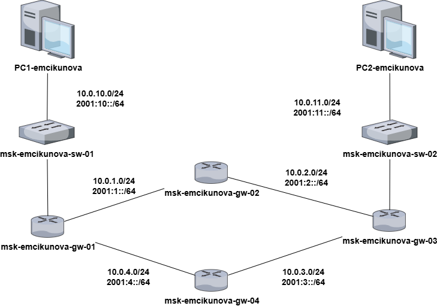

Логическая схема L3 с IPv4- и IPv6-подсетями и альтернативными соединениями между маршрутизаторами

# Настройка динамической маршрутизации OSPFv2

## Включаю протокол OSPFv2 на маршрутизаторах

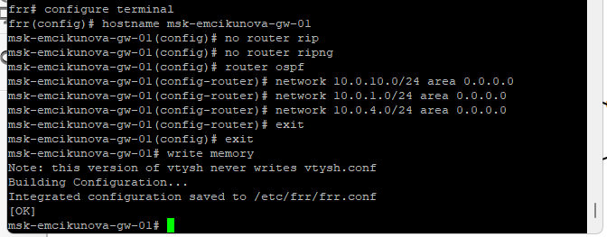

Отключение RIP, включение OSPFv2 и добавление IPv4-сетей в магистральную область 0.0.0.0

## Проверяю соседство и таблицу маршрутизации OSPFv2

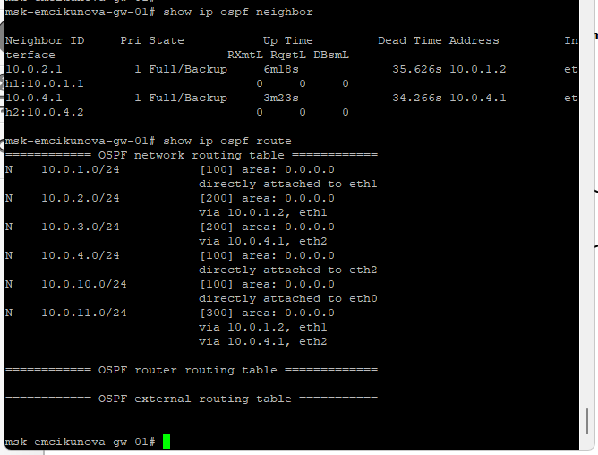

Просмотр соседей OSPFv2, стоимости маршрутов и альтернативных путей к удалённым IPv4-сетям

## Проверяю IPv4-соединение и путь прохождения пакетов

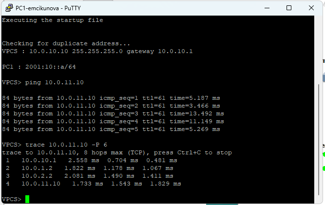

Проверка доступности PC2 с помощью ping и трассировка первоначального IPv4-маршрута через gw-02

# Исследование изменения маршрутов OSPFv2

## Отключаю интерфейс маршрутизатора gw-02

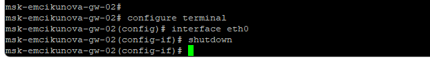

Отключение интерфейса eth0 командой shutdown для моделирования отказа сетевого соединения

## Проверяю переключение на альтернативный IPv4-маршрут

[figure not shown]

Проверка доступности PC2 и трассировка нового IPv4-маршрута через маршрутизатор gw-04

# Анализ OSPFv2 в Wireshark

## Анализирую служебные сообщения OSPFv2 Hello

[figure not shown]

Анализ пакета OSPFv2 Hello, идентификатора маршрутизатора, области OSPF и интервалов Hello и Dead

# Настройка динамической маршрутизации OSPFv3

## Включаю протокол OSPFv3 на маршрутизаторах

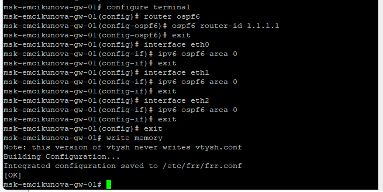

Настройка OSPFv3, назначение Router ID и включение IPv6-интерфейсов в область 0

## Проверяю соседство и таблицу маршрутизации OSPFv3

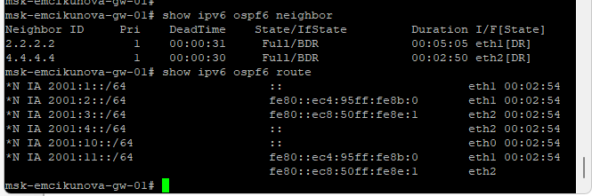

Просмотр соседей OSPFv3, IPv6-маршрутов и следующих переходов на маршрутизаторе gw-01

## Проверяю IPv6-соединение и маршрут передачи пакетов

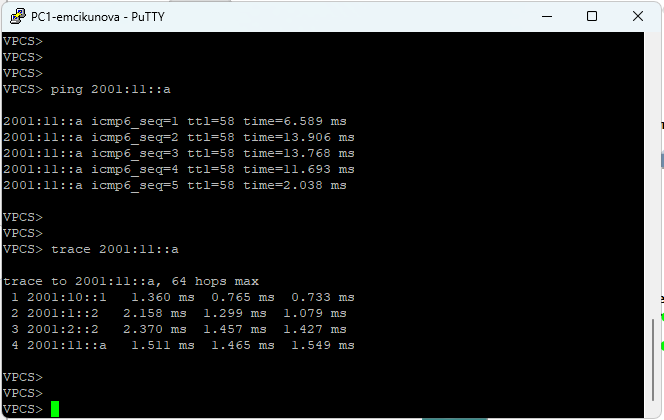

Проверка доступности PC2 по IPv6 и трассировка первоначального маршрута через gw-02

# Исследование изменения маршрутов OSPFv3

## Отключаю интерфейс маршрутизатора gw-02

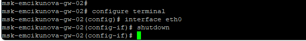

Отключение интерфейса eth0 командой shutdown для проверки перестроения маршрутов OSPFv3

## Проверяю переключение на альтернативный IPv6-маршрут

[figure not shown]

Проверка доступности PC2 и трассировка IPv6-маршрута через gw-04 после отключения соединения

# Анализ OSPFv3 в Wireshark

## Анализирую служебные сообщения OSPFv3 Hello

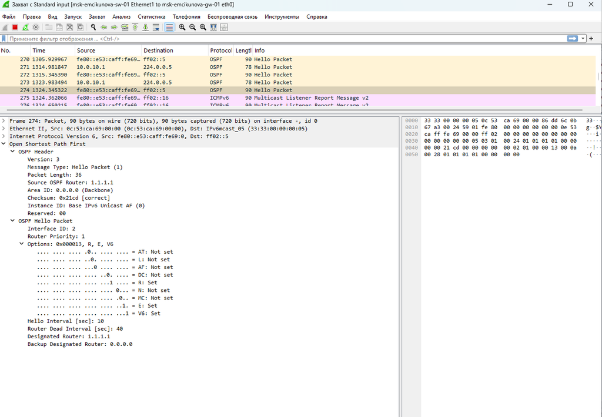

Анализ пакета OSPFv3 Hello, группового IPv6-адреса ff02::5, Router ID и параметров соседства

# Самостоятельное задание

## Использую дополнительную топологию сети

[figure not shown]

Топология самостоятельного задания с четырьмя маршрутизаторами, двумя локальными сетями и альтернативными маршрутами

## Настраиваю протоколы OSPFv2 и OSPFv3

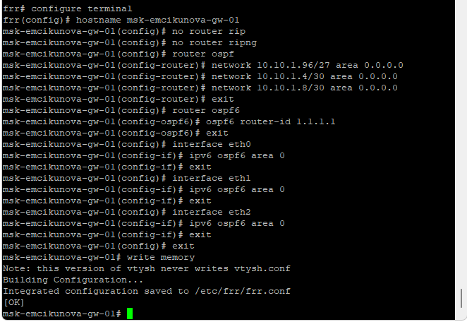

Настройка OSPFv2 и OSPFv3 на маршрутизаторе gw-01 самостоятельного задания

## Проверяю соседство и таблицу маршрутизации OSPFv2

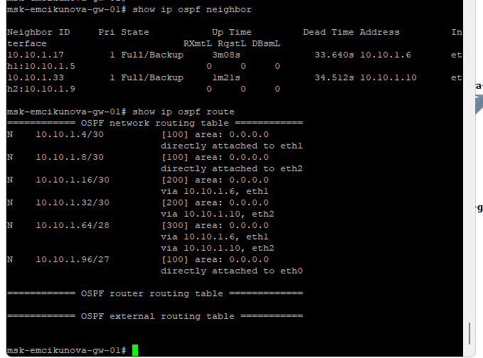

Просмотр соседей OSPFv2, следующих переходов и маршрутов к удалённым IPv4-сетям

## Проверяю соседство и таблицу маршрутизации OSPFv3

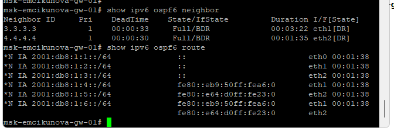

Просмотр соседей OSPFv3, IPv6-префиксов и альтернативных маршрутов на gw-01

## Проверяю соединения от PC1 до PC2 по IPv4 и IPv6

[figure not shown]

Проверка доступности PC2 и трассировка маршрутов IPv4 и IPv6 через маршрутизатор gw-04

## Проверяю соединения от PC2 до PC1 по IPv4 и IPv6

[figure not shown]

Проверка обратной связности и трассировка IPv4-маршрута через gw-03 и IPv6-маршрута через gw-04

# Вывод

## Результаты лабораторной работы

В GNS3 настроена динамическая маршрутизация по протоколам OSPFv2 и OSPFv3 на четырёх маршрутизаторах FRRouting с использованием ранее созданной сети с двойным стеком IPv4 и IPv6.

С помощью команд `show ip ospf neighbor`, `show ip ospf route`, `show ipv6 ospf6 neighbor` и `show ipv6 ospf6 route` проверены отношения соседства, таблицы маршрутизации и стоимость маршрутов. Командами `ping` и `trace` подтверждены доступность удалённых устройств и корректность прохождения пакетов.

При отключении сетевого интерфейса исследовано автоматическое переключение на альтернативный маршрут. В Wireshark проанализированы служебные сообщения OSPFv2 и OSPFv3 Hello, содержащие идентификаторы маршрутизаторов, сведения об областях маршрутизации и временные параметры протокола.